# 17_rotate_2D

## 17_rotate_2D

#### Question

1. A video-game developer is hoping to rotate a set of points around the origin by 0.829 radians counterclockwise by using matrix multiplication.

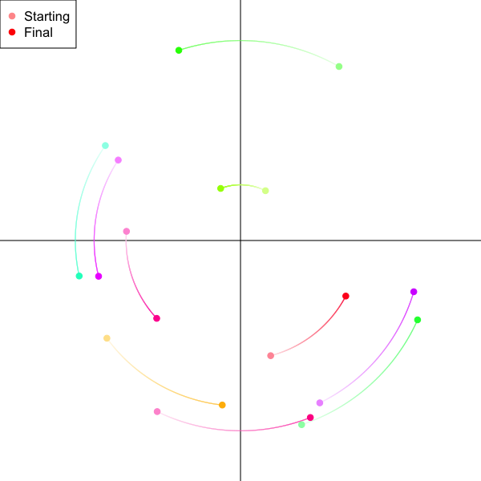

   The starting points are stored as rows in a 10 $\times$ 2 matrix $S$.

   $$S=\begin{bmatrix}
   3.56 & -7.291\\
   -3.741 & -7.683\\
   -5.12 & 0.412\\
   2.746 & -8.27\\
   -6.069 & 4.263\\
   4.425 & 7.813\\
   1.355 & -5.172\\
   1.122 & 2.236\\
   -6 & -4.388\\
   -5.49 & 3.613
   \end{bmatrix}$$

   The 2D-rotation matrix can be found by using $\theta=0.829$ in the formula below.

   $$R~=~\begin{bmatrix}\cos(\theta)&\sin(\theta)\\ -\sin(\theta) & \cos(\theta)\end{bmatrix}$$

   The final points (in matrix $F$) are found by multiplying $S\cdot R$.

   $$F=S\cdot R$$

   That multiplication can be done using the diagram below.

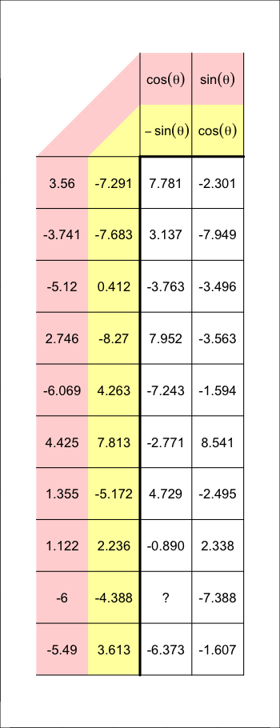

   As denoted by the question mark in the diagram above, when the point $(-6,-4.388)$ is rotated by 0.829 radians, what is the new $x$ coordinate?

#### Question

2. A video-game developer is hoping to rotate a set of points around the origin by 0.817 radians counterclockwise by using matrix multiplication.

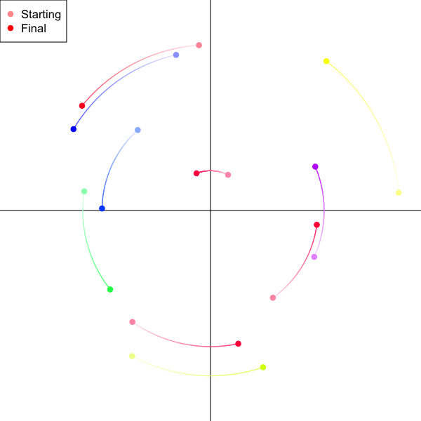

   The starting points are stored as rows in a 10 $\times$ 2 matrix $S$.

   $$S=\begin{bmatrix}
   -4.007 & -5.716\\
   -3.732 & 4.128\\
   9.656 & 0.91\\
   -4.019 & -7.47\\
   5.321 & -2.379\\
   -0.591 & 8.482\\
   0.9 & 1.83\\
   -6.477 & 0.983\\
   -1.765 & 7.982\\
   3.2 & -4.478
   \end{bmatrix}$$

   The 2D-rotation matrix can be found by using $\theta=0.817$ in the formula below.

   $$R~=~\begin{bmatrix}\cos(\theta)&\sin(\theta)\\ -\sin(\theta) & \cos(\theta)\end{bmatrix}$$

   The final points (in matrix $F$) are found by multiplying $S\cdot R$.

   $$F=S\cdot R$$

   That multiplication can be done using the diagram below.

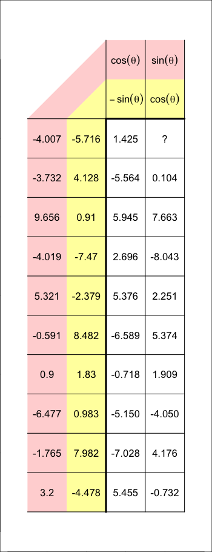

   As denoted by the question mark in the diagram above, when the point $(-4.007,-5.716)$ is rotated by 0.817 radians, what is the new $y$ coordinate?

#### Question

3. A video-game developer is hoping to rotate a set of points around the origin by 0.595 radians counterclockwise by using matrix multiplication.

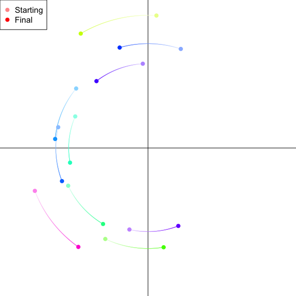

   The starting points are stored as rows in a 10 $\times$ 2 matrix $S$.

   $$S=\begin{bmatrix}
   0.616 & 9.665\\
   -3.116 & -6.638\\
   -5.31 & 2.304\\
   -5.243 & 4.342\\
   -1.356 & -5.949\\
   -0.379 & 6.15\\
   -8.256 & -3.128\\
   -6.553 & 1.517\\
   -5.825 & -2.754\\
   2.394 & 7.229
   \end{bmatrix}$$

   The 2D-rotation matrix can be found by using $\theta=0.595$ in the formula below.

   $$R~=~\begin{bmatrix}\cos(\theta)&\sin(\theta)\\ -\sin(\theta) & \cos(\theta)\end{bmatrix}$$

   The final points (in matrix $F$) are found by multiplying $S\cdot R$.

   $$F=S\cdot R$$

   That multiplication can be done using the diagram below.

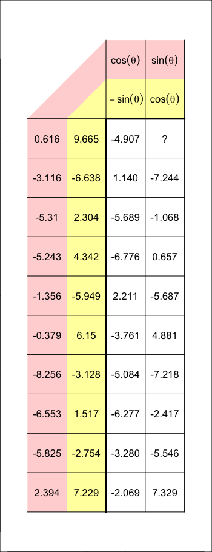

   As denoted by the question mark in the diagram above, when the point $(0.616,9.665)$ is rotated by 0.595 radians, what is the new $y$ coordinate?

#### Question

4. A video-game developer is hoping to rotate a set of points around the origin by 1.054 radians counterclockwise by using matrix multiplication.

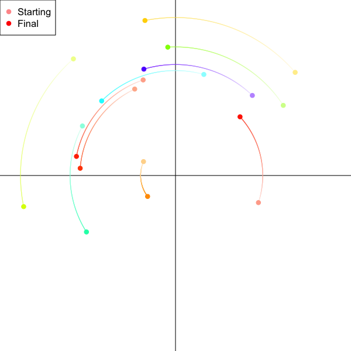

   The starting points are stored as rows in a 10 $\times$ 2 matrix $S$.

   $$S=\begin{bmatrix}
   -5.728 & 3.048\\
   -1.969 & 0.856\\
   7.364 & 6.347\\
   -6.282 & 7.177\\
   6.632 & 4.315\\
   5.103 & -1.668\\
   1.744 & 6.218\\
   -1.99 & 5.88\\
   4.729 & 4.927\\
   -2.51 & 5.319
   \end{bmatrix}$$

   The 2D-rotation matrix can be found by using $\theta=1.054$ in the formula below.

   $$R~=~\begin{bmatrix}\cos(\theta)&\sin(\theta)\\ -\sin(\theta) & \cos(\theta)\end{bmatrix}$$

   The final points (in matrix $F$) are found by multiplying $S\cdot R$.

   $$F=S\cdot R$$

   That multiplication can be done using the diagram below.

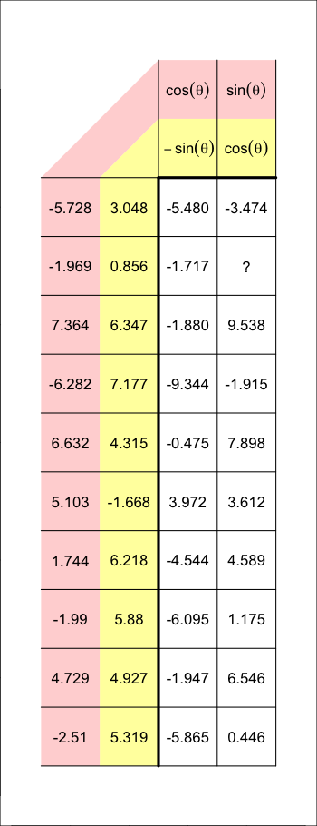

   As denoted by the question mark in the diagram above, when the point $(-1.969,0.856)$ is rotated by 1.054 radians, what is the new $y$ coordinate?

#### Question

5. A video-game developer is hoping to rotate a set of points around the origin by 0.536 radians counterclockwise by using matrix multiplication.

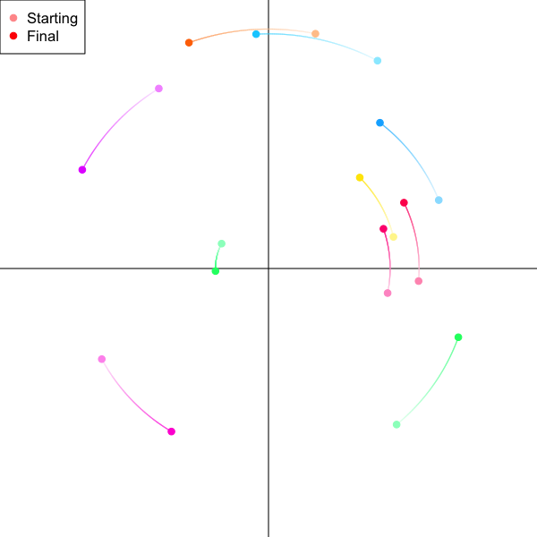

   The starting points are stored as rows in a 10 $\times$ 2 matrix $S$.

   $$S=\begin{bmatrix}
   -1.886 & 1\\
   5.025 & 1.271\\
   -4.412 & 7.24\\
   -6.706 & -3.645\\
   4.385 & 8.359\\
   6.037 & -0.506\\
   1.888 & 9.444\\
   4.791 & -0.988\\
   6.848 & 2.751\\
   5.153 & -6.277
   \end{bmatrix}$$

   The 2D-rotation matrix can be found by using $\theta=0.536$ in the formula below.

   $$R~=~\begin{bmatrix}\cos(\theta)&\sin(\theta)\\ -\sin(\theta) & \cos(\theta)\end{bmatrix}$$

   The final points (in matrix $F$) are found by multiplying $S\cdot R$.

   $$F=S\cdot R$$

   That multiplication can be done using the diagram below.

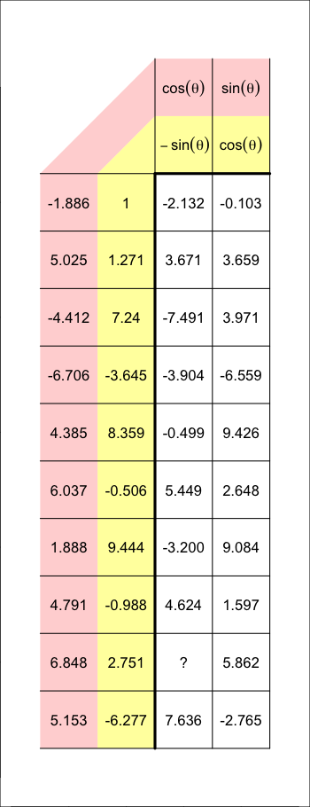

   As denoted by the question mark in the diagram above, when the point $(6.848,2.751)$ is rotated by 0.536 radians, what is the new $x$ coordinate?

#### Question

6. A video-game developer is hoping to rotate a set of points around the origin by 0.41 radians counterclockwise by using matrix multiplication.

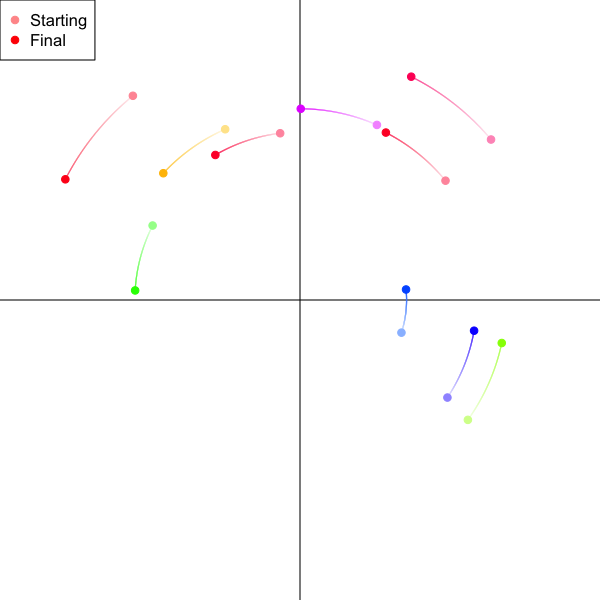

   The starting points are stored as rows in a 10 $\times$ 2 matrix $S$.

   $$S=\begin{bmatrix}
   -2.694 & 6.147\\
   6.877 & 5.777\\
   -0.714 & 6.003\\
   -6.016 & 7.352\\
   5.307 & -3.512\\
   5.238 & 4.296\\
   -5.306 & 2.681\\
   3.652 & -1.175\\
   6.044 & -4.315\\
   2.769 & 6.303
   \end{bmatrix}$$

   The 2D-rotation matrix can be found by using $\theta=0.41$ in the formula below.

   $$R~=~\begin{bmatrix}\cos(\theta)&\sin(\theta)\\ -\sin(\theta) & \cos(\theta)\end{bmatrix}$$

   The final points (in matrix $F$) are found by multiplying $S\cdot R$.

   $$F=S\cdot R$$

   That multiplication can be done using the diagram below.

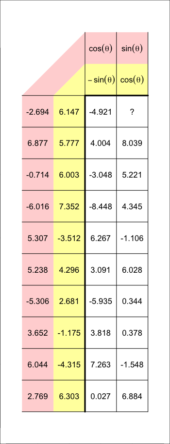

   As denoted by the question mark in the diagram above, when the point $(-2.694,6.147)$ is rotated by 0.41 radians, what is the new $y$ coordinate?

#### Question

7. A video-game developer is hoping to rotate a set of points around the origin by 0.98 radians counterclockwise by using matrix multiplication.

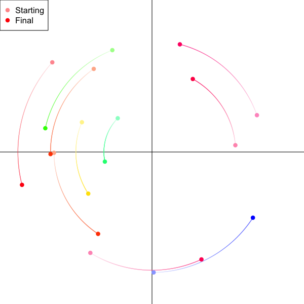

   The starting points are stored as rows in a 10 $\times$ 2 matrix $S$.

   $$S=\begin{bmatrix}
   -6.966 & -0.058\\
   0.116 & -8.556\\
   -2.819 & 7.237\\
   -2.434 & 2.399\\
   -4.381 & -7.168\\
   -4.98 & 2.114\\
   -7.084 & 6.371\\
   -4.139 & 5.905\\
   5.923 & 0.483\\
   7.456 & 2.617
   \end{bmatrix}$$

   The 2D-rotation matrix can be found by using $\theta=0.98$ in the formula below.

   $$R~=~\begin{bmatrix}\cos(\theta)&\sin(\theta)\\ -\sin(\theta) & \cos(\theta)\end{bmatrix}$$

   The final points (in matrix $F$) are found by multiplying $S\cdot R$.

   $$F=S\cdot R$$

   That multiplication can be done using the diagram below.

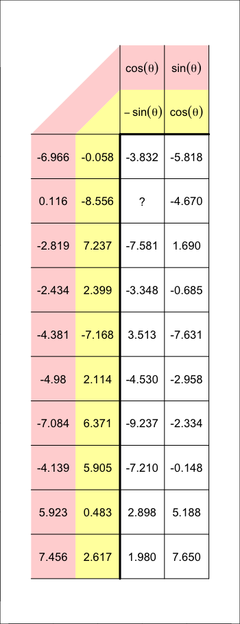

   As denoted by the question mark in the diagram above, when the point $(0.116,-8.556)$ is rotated by 0.98 radians, what is the new $x$ coordinate?

#### Question

8. A video-game developer is hoping to rotate a set of points around the origin by 1.146 radians counterclockwise by using matrix multiplication.

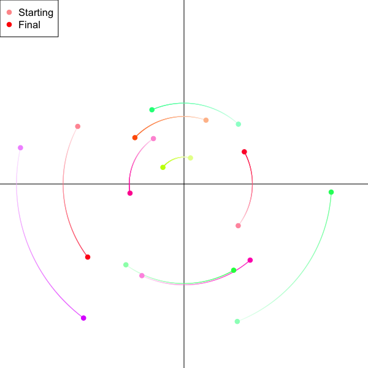

   The starting points are stored as rows in a 10 $\times$ 2 matrix $S$.

   $$S=\begin{bmatrix}
   -9.598 & 2.129\\
   3.127 & -8.069\\
   3.182 & -2.447\\
   3.193 & 3.511\\
   -1.795 & 2.666\\
   1.291 & 3.747\\
   0.38 & 1.531\\
   -3.41 & -4.742\\
   -6.238 & 3.381\\
   -2.472 & -5.379
   \end{bmatrix}$$

   The 2D-rotation matrix can be found by using $\theta=1.146$ in the formula below.

   $$R~=~\begin{bmatrix}\cos(\theta)&\sin(\theta)\\ -\sin(\theta) & \cos(\theta)\end{bmatrix}$$

   The final points (in matrix $F$) are found by multiplying $S\cdot R$.

   $$F=S\cdot R$$

   That multiplication can be done using the diagram below.

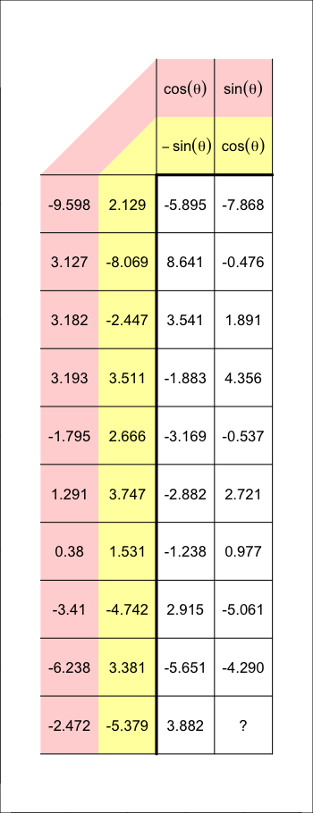

   As denoted by the question mark in the diagram above, when the point $(-2.472,-5.379)$ is rotated by 1.146 radians, what is the new $y$ coordinate?